# Random Forest Model Results

last-modified

## City Scale

```r
tar_load(cities_lst_full)
```

```
## → reading _targets/meta/meta
```

```r
cities_lst_df <- cities_lst_full %>%
  # remove irrelevant columns
  select(-c(time, count_temp, median_temp, max_temp, min_temp,
            stdDev_temp, coverage, stemdens_acre, total_ba,
            centroids, build_area, road_length, area, da,
            DAcount, lowinc, date_ndvi, time_ndvi, NDBI_count_,
            NDBI_median_, NDBI_max_, NDBI_min_, NDBI_stdDev_,
            NDVI_count_, NDVI_median_, NDVI_max_, NDVI_min_,
            NDVI_stdDev_, diff)) %>%
  # make character variables into factors s
  mutate_if(is.character, factor) %>%
  # convert date into doy
  mutate(doy = yday(date)) %>%
  select(-date)

# drop units from all columns to turn them into numeric class
cities_lst_df <- drop_units(cities_lst_df)

# add lat / long of cities?
```

After prepping dataset, we check for correlations across variables :

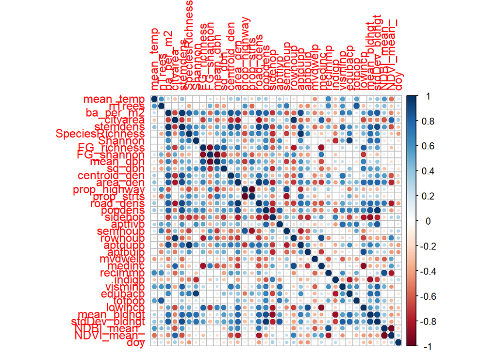

```r
cities_lst_df %>%
  select_if(is.numeric) %>%
  cor(use = "complete.obs") %>%
  corrplot::corrplot()
```

There are a lot of correlations in the variables at this scale, we can use a `step_corr()` function to automate their removal, or do it by hand. We will proceed with the `step_corr()` function.

Now, we start to specify our model:

```r
set.seed(123)
# strata ensures that the random sampling is conducted within the stratification variable
# resamples have equivalent proportions of the original dataset
df_split <- initial_split(cities_lst_df, strata = city)
df_train <- training(df_split)
df_test <- testing(df_split)


# this is the model, everything in the dataset is explanatory except legal status and ID
mod_rec <- recipe(mean_temp ~ ., data = df_train) %>%
  # normalize all continuous vars
  step_normalize(all_numeric_predictors(), -doy) %>%
  # converts factors (nominal) into numeric binary model terms
  step_dummy(all_nominal(), -all_outcomes()) %>%
  # set correlation threshold to 0.8
  step_corr(threshold = 0.8) %>%
  # remove variables that have near zero variation
  step_nzv()


# tune hyperparameters mtry and min_n
tune_spec <- rand_forest(
  mtry = tune(), # number of predictors that will be randomly sampled at each split
  trees = 1000,
  min_n = tune() # min number of data points in a node required for the node to split further
) %>%
  # regression is trying to predict/fit numeric values
  set_mode("regression") %>%
  # type of computational engine -> dependent on model type
  # ranger is default and allows tuning of hyperparameters
  set_engine("ranger")

# put everything together in a workflow
tune_wf <- workflow() %>%
  add_recipe(mod_rec) %>%
  add_model(tune_spec)
```

After this, we want to tune our hyperparameters so that we select the ones with the best performance

```r
set.seed(234)

# random splits of the data into V groups of roughly equal size
# using boostrap because small dataset
mod_folds <- bootstraps(df_train)

# need to assess across many models - use parallel processing to use 20 grid points
future::plan(strategy = 'multisession')

set.seed(345)
# computes performance metrics for tuning parameters (set in tune_wf) for resamples (trees_folds)
tune_res <- tune_grid(
  tune_wf,
  resamples = mod_folds,
  # data frame of tuning combinations with 25 candidate parameter sets
  grid = 25,
  control = control_grid(save_pred = T),
  metrics = metric_set(mae, rsq))
```

Assess the performance of different hyperparameter values

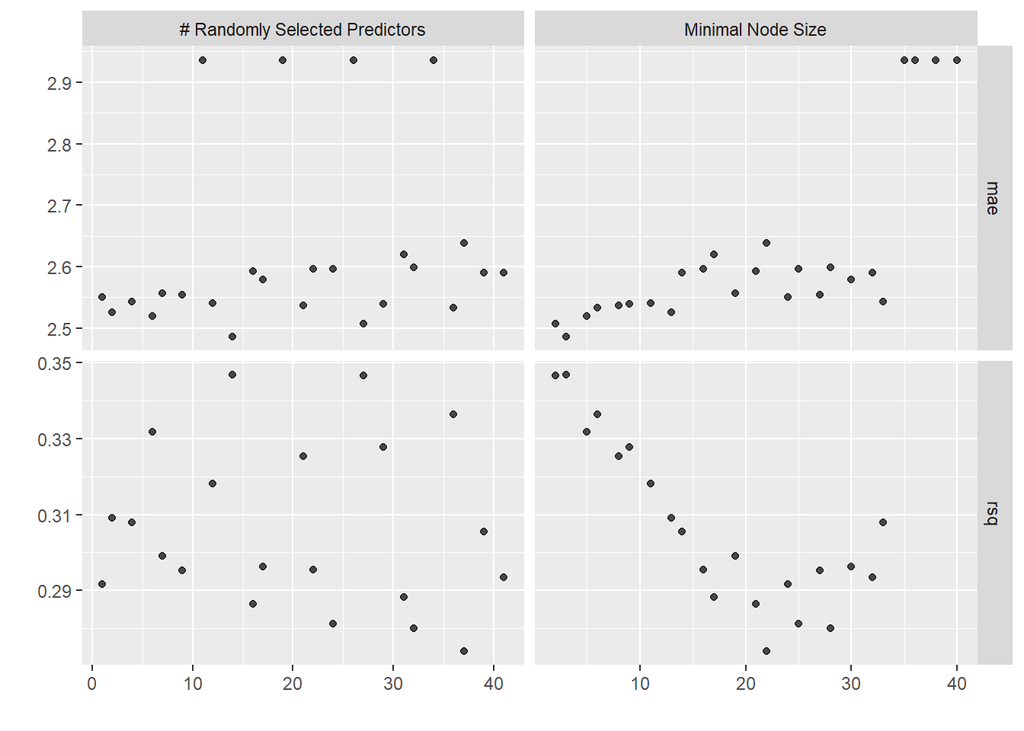

```r
autoplot(tune_res)
```

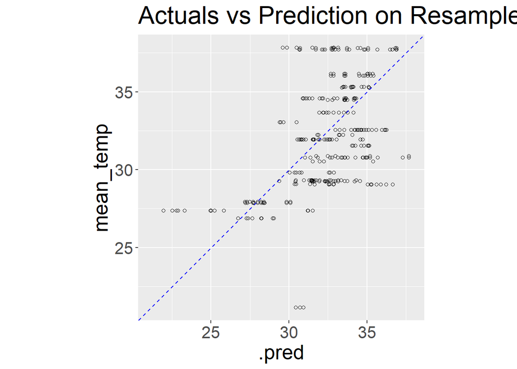

```r
# select best values for hyperparameters and fit model
best_auc <- select_best(tune_res, metric = "mae")


# look at predictions of best model against real values
collect_predictions(tune_res) %>%
  filter(.config==pull(show_best(tune_res, metric='mae', n=1),.config)) %>% # only bring back predictions for the best model
  ggplot(aes(x=.pred, y=mean_temp )) +
  geom_point(shape=1)  +
  geom_abline(slope=1, linetype = "dashed", colour='blue') +
  coord_obs_pred() +
  ggtitle("Actuals vs Prediction on Resamples") +
  theme(text = element_text(size=20))
```

Update model to include variance importance scores and fit best model to test data

```r
cores <- parallel::detectCores()

last_mod <-
  rand_forest(mtry = best_auc$mtry, min_n = best_auc$min_n, trees = 1000) %>%
  set_mode("regression") %>%
  set_engine("ranger", num.threads = cores, importance = "impurity")


# the last workflow
last_workflow <-
  tune_wf %>%
  update_model(last_mod)

# the last fit
set.seed(345)
last_rf_fit <-
  last_workflow %>%
  last_fit(df_split,
           metrics = metric_set(mae, rsq))
```

Now we can assess the performance of the final model. We want metrics to stay consistent across testing and training data.

```r
# performance metrics values for top validation model and test model
tune_res %>%
  collect_metrics() %>%
  inner_join(., best_auc) %>%
  mutate(model = 'validation',
         .estimate = mean) %>%
  select(c(.metric, .estimator, .estimate, .config, model)) %>%
  rbind(., last_rf_fit %>% collect_metrics() %>% mutate(model = 'test'))
```

```
## # A tibble: 4 × 5
##   .metric .estimator .estimate .config               model
##   <chr>   <chr>          <dbl> <chr>                 <chr>
## 1 mae     standard       2.49  Preprocessor1_Model09 validation
## 2 rsq     standard       0.347 Preprocessor1_Model09 validation
## 3 mae     standard       2.53  Preprocessor1_Model1  test
## 4 rsq     standard       0.487 Preprocessor1_Model1  test
```

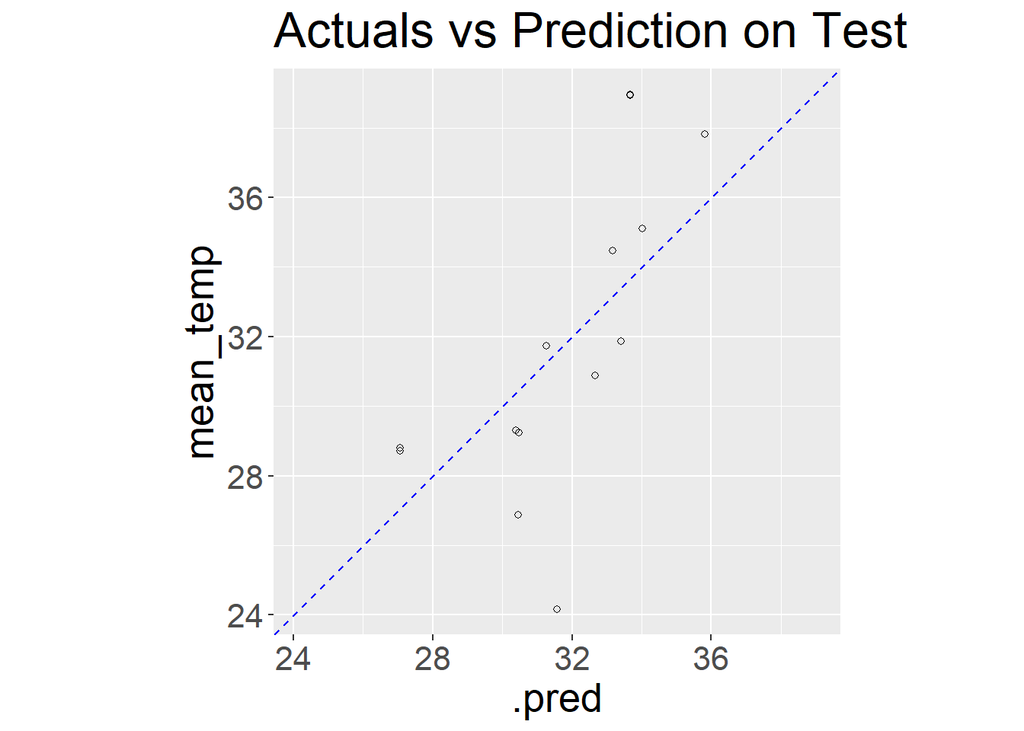

```r
# performance decreases on real data model


# prediction vs actual values for final model
collect_predictions(last_rf_fit) %>%
  ggplot(aes(x=.pred, y=mean_temp )) +
  geom_point(shape=1)  +
  geom_abline(slope=1, linetype = "dashed", colour='blue') +
  coord_obs_pred() +
  ggtitle("Actuals vs Prediction on Test") +
  theme(text = element_text(size=20))
```

The city model is not great at predicting data. This makes sense, it is a small dataset with a lot of autocorrelation. The test data performs better than the training data, though ideally these metrics would be similar across groups. This model is weak.

The worst predictions seem to be at very low and very high mean temperatures.

Let’s see what the most important variables in our model are

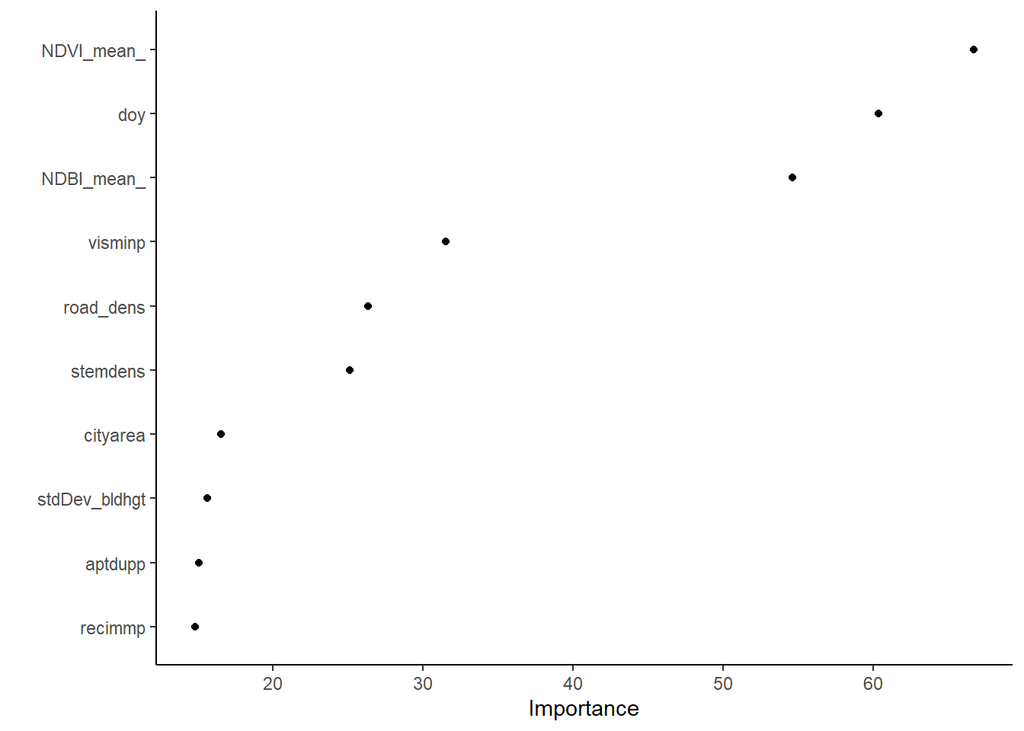

```r
vip <- last_rf_fit %>%
  extract_fit_parsnip() %>%
  vip(geom = "point") +
  theme_classic()

vip
```

We only see 1 street tree variable in the 10 most important variables at this scale. What are the relationships for each city of these top variables?

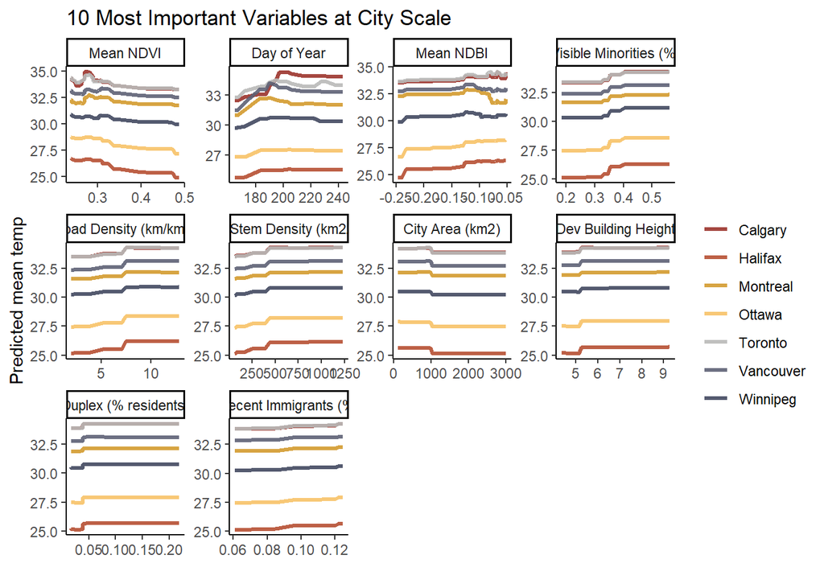

```r
model_explainer <- explain_tidymodels(
  last_rf_fit$.workflow[[1]],
  data = df_train,
  y = as.integer(df_train$mean_temp),
  verbose = FALSE
)

vars <- vip[["data"]]$Variable


pdp_time <- model_profile(
  model_explainer,
  variables = vars,
  N = NULL,
  groups = "city"
)

supp.labs <- c("Mean NDVI", "Day of Year", "Mean NDBI", "Visible Minorities (%)", "Road Density (km/km2)", "Tree Stem Density (km2/km2)", "City Area (km2)", "Std Dev Building Height (m)", "Duplex (% residents)", "Recent Immigrants (%)")
names(supp.labs) <- vars

as_tibble(pdp_time$agr_profiles) %>%
  mutate(across(`_vname_`, ~factor(., levels=vars))) %>%
  ggplot(aes(`_x_`, `_yhat_`, color = `_groups_`)) +
  scale_color_met_d(name = 'Demuth') +
  #geom_point(data = df_train, aes(x = stemdens, y = mean_temp, colour = city)) +
  geom_line(linewidth = 1.2, alpha = 0.9) +
  labs(
    title = "10 Most Important Variables at City Scale",
    y = "Predicted mean temp",
    colour = "",
    x = ""
  ) +
  facet_wrap(`_vname_` ~ ., scales = "free", labeller = labeller(`_vname_` = supp.labs)) +
  theme_classic()
```

## Neighbourhood Scale

The code is the same so we will only be looking at table and figure outputs.

Load and prep data for models:

```
## → reading _targets/meta/meta
```

After prepping dataset, we check for correlations across variables :

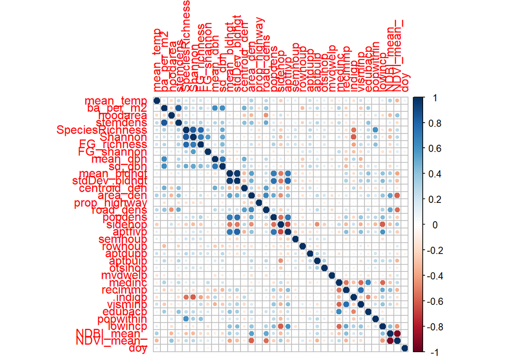

There are a couple strong correlations in the variables at this scale. We will proceed with the `step_corr()` function. We will use cross-fold validation instead of bootstrapping at this scale, because we have enough samples.

After this, we want to tune our hyperparameters so that we select the ones with the best performance

Assess the performance of different hyperparameter values

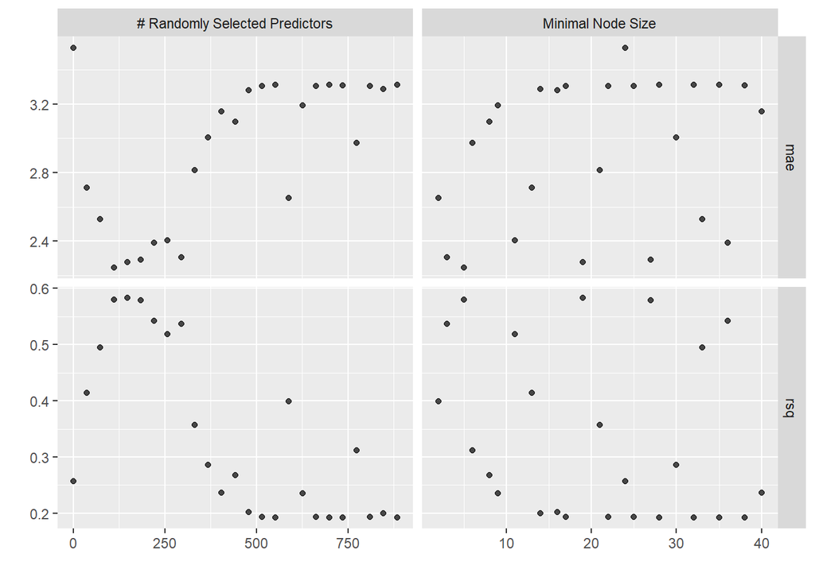

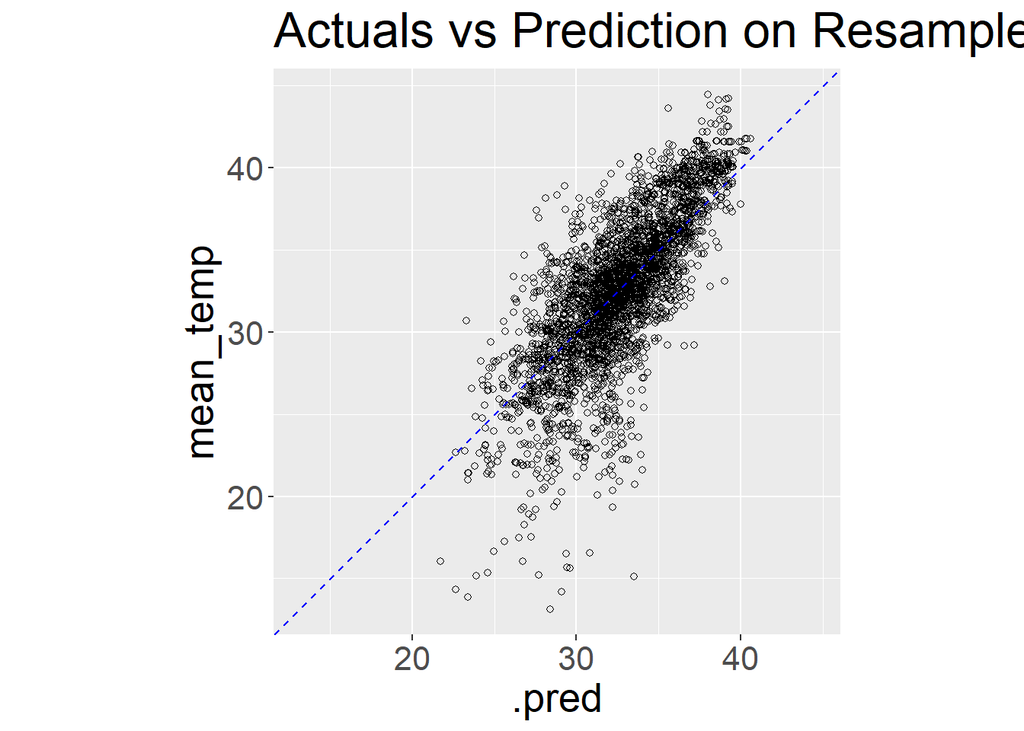

Update model to include variance importance scores and fit best model to test data

Now we can assess the performance of the final model. We want metrics to stay consistent across testing and training data.

```
## # A tibble: 4 × 5
##   .metric .estimator .estimate .config               model
##   <chr>   <chr>          <dbl> <chr>                 <chr>
## 1 mae     standard       2.25  Preprocessor1_Model04 validation
## 2 rsq     standard       0.580 Preprocessor1_Model04 validation
## 3 mae     standard       2.18  Preprocessor1_Model1  test
## 4 rsq     standard       0.590 Preprocessor1_Model1  test
```

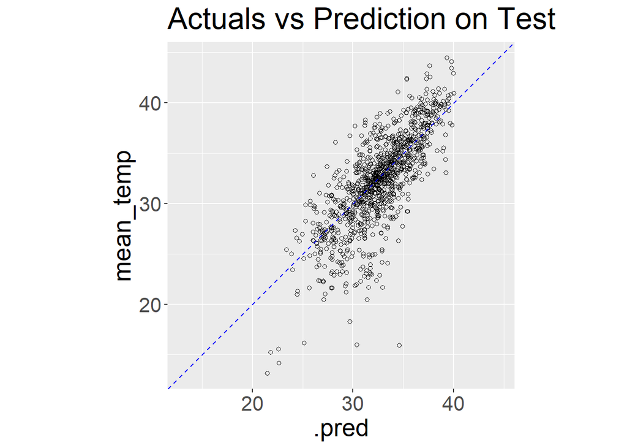

The worst predictions seem to be at very low and very high mean temperatures.

Let’s see what the most important variables in our model are

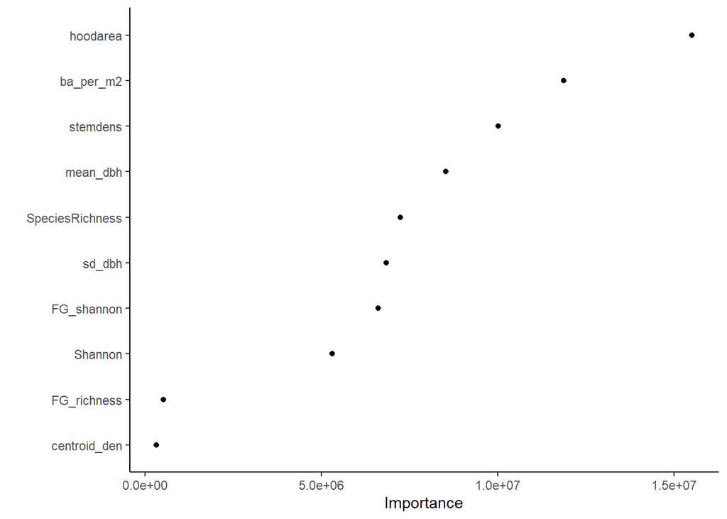

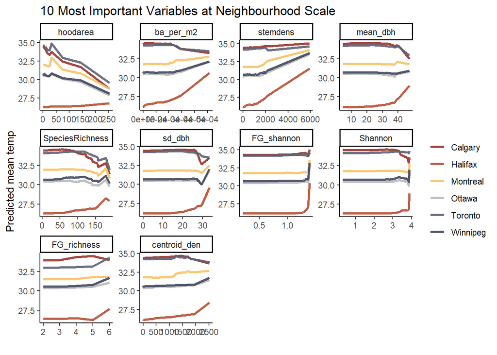